# Machine Learning Predictions

Luis A Alaniz Castillo

3/25/2018

### Packages used.

```r
library(dplyr)
library(Hmisc)
library(caret)
library(pgmm)
library(rpart)
library(gbm)
library(e1071)
library(randomForest)
library(gplots)
library(RColorBrewer)
```

### Loading the data.

The root directory was setup using the knitr option root.dir and then the data was downloaded that directory, if not already downlaoded before, and loaded into R using the R command read.csv. The data was then store in a table data frame.

```r
if (!file.exists("pml-training.csv") & !file.exists("pml-testing.csv")) {
        fileurl_train = "https://d396qusza40orc.cloudfront.net/predmachlearn/pml-training.csv"
        fileurl_test = "https://d396qusza40orc.cloudfront.net/predmachlearn/pml-testing.csv"
        download.file(fileurl_train, "pml-training.csv")
        download.file(fileurl_test, "pml-testing.csv")
        dateDownloaded <- date()
}

data_train <- read.csv("pml-training.csv")
data_test <- read.csv("pml-testing.csv")
data_train <- tbl_df(data_train)
data_test <- tbl_df(data_test)
```

### Partioning the data in a train and a validation set.

The validation set consists of 25 percent of the original training set and the new training set consists 75 percent of the original training set.

```r
data_train <- read.csv("pml-training.csv")
data_test <- read.csv("pml-testing.csv")
inTrain <- createDataPartition(data_train$classe, p = 3/4)[[1]]
data_val <- data_train[ -inTrain,]
data_train = data_train[inTrain,]

data_train <- tbl_df(data_train)
data_val <- tbl_df(data_val)
data_test <- tbl_df(data_test)
```

### Exploring and selecting the data.

Eliminated names and observations numbers as they are irrelevant for prediction. Also eliminated timestamps and windows variables because they are irrelevant in this application of machine learning algorithms since forecasting will not be used. Finally, eliminated average, variance, standard deviation, max, min, amplitude, skewness and kurtosis features since they do not exist for every variables.

```r
data_train <- select(data_train, -X, -user_name, -raw_timestamp_part_1, -raw_timestamp_part_2, -cvtd_timestamp, -new_window, -num_window)
data_val <- select(data_val, -X, -user_name, -raw_timestamp_part_1, -raw_timestamp_part_2, -cvtd_timestamp, -new_window, -num_window)

drops <- c(grep("^avg",names(data_train), value = TRUE), grep("^var",names(data_train), value = TRUE),
           grep("^stddev",names(data_train), value = TRUE), grep("^max",names(data_train), value = TRUE),
           grep("^min",names(data_train), value = TRUE), grep("^amplitude",names(data_train), value = TRUE),
           grep("^skewness",names(data_train), value = TRUE), grep("^kurtosis",names(data_train), value = TRUE))

data_train <-  data_train[ , !(names(data_train) %in% drops)]
data_val <-  data_val[ , !(names(data_val) %in% drops)]
data_train
```

```
## # A tibble: 14,718 x 53
##    roll_belt pitch_belt yaw_belt total_accel_belt gyros_belt_x
##        <dbl>      <dbl>    <dbl>            <int>        <dbl>
##  1      1.41       8.07    -94.4                3       0.
##  2      1.42       8.07    -94.4                3       0.
##  3      1.48       8.05    -94.4                3       0.0200
##  4      1.48       8.07    -94.4                3       0.0200
##  5      1.45       8.06    -94.4                3       0.0200
##  6      1.42       8.09    -94.4                3       0.0200
##  7      1.43       8.16    -94.4                3       0.0200
##  8      1.45       8.17    -94.4                3       0.0300
##  9      1.45       8.18    -94.4                3       0.0300
## 10      1.43       8.18    -94.4                3       0.0200
## # ... with 14,708 more rows, and 48 more variables: gyros_belt_y <dbl>,
## #   gyros_belt_z <dbl>, accel_belt_x <int>, accel_belt_y <int>,
## #   accel_belt_z <int>, magnet_belt_x <int>, magnet_belt_y <int>,
## #   magnet_belt_z <int>, roll_arm <dbl>, pitch_arm <dbl>, yaw_arm <dbl>,
## #   total_accel_arm <int>, gyros_arm_x <dbl>, gyros_arm_y <dbl>,
## #   gyros_arm_z <dbl>, accel_arm_x <int>, accel_arm_y <int>,
## #   accel_arm_z <int>, magnet_arm_x <int>, magnet_arm_y <int>,
## #   magnet_arm_z <int>, roll_dumbbell <dbl>, pitch_dumbbell <dbl>,
## #   yaw_dumbbell <dbl>, total_accel_dumbbell <int>,
## #   gyros_dumbbell_x <dbl>, gyros_dumbbell_y <dbl>,
## #   gyros_dumbbell_z <dbl>, accel_dumbbell_x <int>,
## #   accel_dumbbell_y <int>, accel_dumbbell_z <int>,
## #   magnet_dumbbell_x <int>, magnet_dumbbell_y <int>,
## #   magnet_dumbbell_z <dbl>, roll_forearm <dbl>, pitch_forearm <dbl>,
## #   yaw_forearm <dbl>, total_accel_forearm <int>, gyros_forearm_x <dbl>,
## #   gyros_forearm_y <dbl>, gyros_forearm_z <dbl>, accel_forearm_x <int>,
## #   accel_forearm_y <int>, accel_forearm_z <int>, magnet_forearm_x <int>,
## #   magnet_forearm_y <dbl>, magnet_forearm_z <dbl>, classe <fct>
```

### Training and validating.

- Tree and its precision.

```r
tree <- train(classe ~ ., data = data_train, method =  "rpart")
#par(mfrow = c(1,1), oma = c(4.1, 2.1, 5.1, 2.1), mar = c(0, 0, 6, 0))
#plot(tree$finalModel, uniform = TRUE, main = "Classification Tree")
#text(tree$finalModel, use.n = TRUE, all = TRUE, cex = 0.5)
#par(mfrow=c(1,1))

pred_tree <- predict(tree, data_val)
conf_tree <- confusionMatrix(pred_tree, data_val$classe)

round(conf_tree$overall,2)
```

```
##       Accuracy          Kappa  AccuracyLower  AccuracyUpper   AccuracyNull
##           0.49           0.34           0.48           0.51           0.28
## AccuracyPValue  McnemarPValue
##           0.00            NaN
```

- Tree confusion matrix.

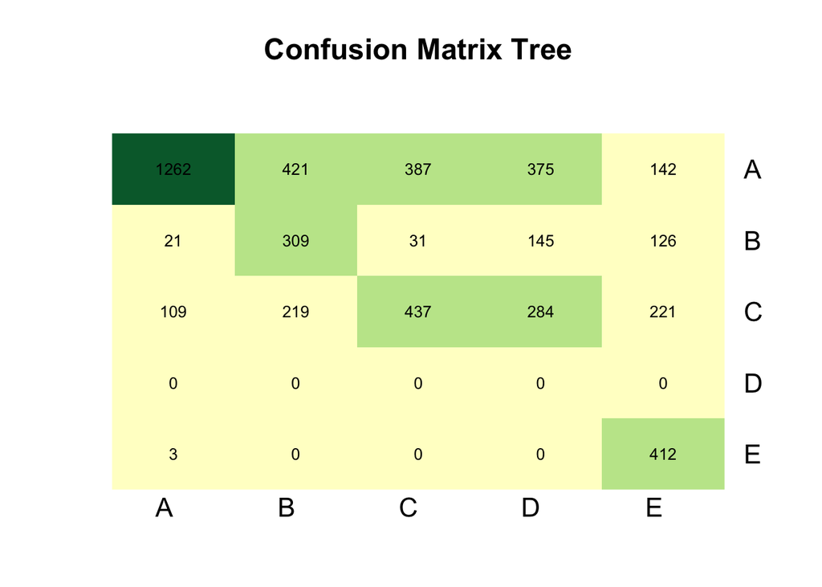

```r
palette <- brewer.pal(n = 5, name = "YlGn")
heatmap.2(conf_tree$table, dendrogram='none', Rowv = FALSE, Colv = FALSE, key = FALSE, col = palette, cellnote = as.matrix(conf_tree$table), trace = "none", notecol = "black", lwid = c(1.5,9.5), lhei = c(2.5,8.5), srtCol = 360, main = "Confusion Matrix Tree")
```

```r
par(mfrow=c(1,1))
```

- Tree bagging and its precision.

```r
tree_bag <- train(classe ~ ., data = data_train, method =  "treebag")
pred_tree_bag <- predict(tree_bag, data_val)
conf_tree_bag <- confusionMatrix(pred_tree_bag, data_val$classe)

round(conf_tree_bag$overall,2)
```

```
##       Accuracy          Kappa  AccuracyLower  AccuracyUpper   AccuracyNull
##           0.98           0.98           0.98           0.99           0.28
## AccuracyPValue  McnemarPValue
##           0.00           0.01
```

- Tree bagging confusion matrix.

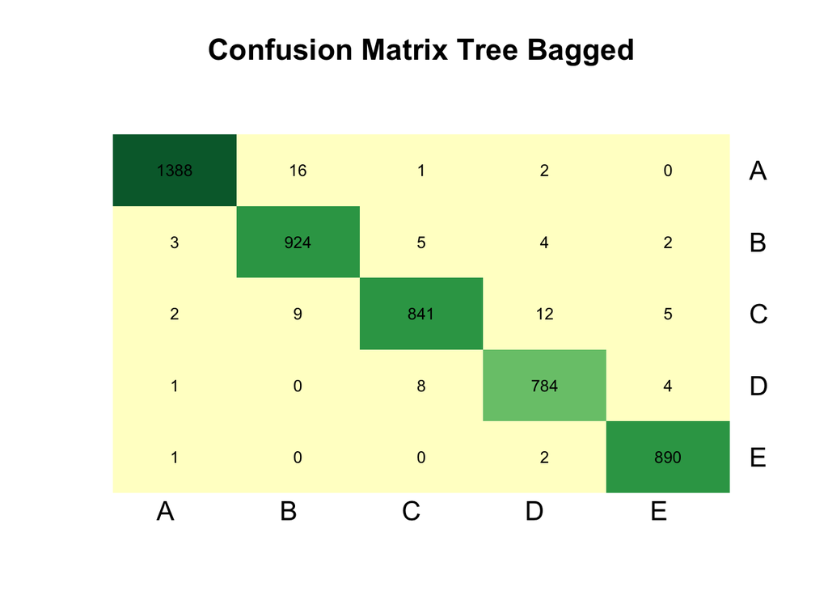

```r
palette <- brewer.pal(n = 5, name = "YlGn")
heatmap.2(conf_tree_bag $table, dendrogram='none', Rowv = FALSE, Colv = FALSE, key = FALSE, col = palette, cellnote = as.matrix(conf_tree_bag $table), trace = "none", notecol = "black", lwid = c(1.5,9.5), lhei = c(2.5,8.5), srtCol = 360, main = "Confusion Matrix Tree Bagged")
```

```r
par(mfrow=c(1,1))
```

- Random forest and its precision.

```r
forest <- randomForest(classe ~ ., data = data_train, importance =  TRUE)
pred_forest <- predict(forest, data_val)
conf_forest <- confusionMatrix(pred_forest, data_val$classe)

round(conf_forest$overall,2)
```

```
##       Accuracy          Kappa  AccuracyLower  AccuracyUpper   AccuracyNull
##           1.00           0.99           0.99           1.00           0.28
## AccuracyPValue  McnemarPValue
##           0.00            NaN
```

[figure not shown]

```r
palette <- brewer.pal(n = 5, name = "YlGn")
heatmap.2(conf_forest$table, dendrogram='none', Rowv = FALSE, Colv = FALSE, key = FALSE, col = palette, cellnote = as.matrix(conf_tree$table), trace = "none", notecol = "black", lwid = c(1.5,9.5), lhei = c(2.5,8.5), srtCol = 360, main = "Confusion Matrix Random Forest")
```

### Conclusion

Random Forest appears to be the most precise method. Boosting was practically infeaseable because of computing time (to many variables and observations for this algorithm to work in a reasonable amount of time).